# Project: Investigate a Dataset - [Cell Phone Dataset]

- Introduction
- Data Wrangling
- Exploratory Data Analysis
- Conclusions

## Introduction

### Dataset Description

> In this project, I am going to investigate the total number of cell phones per country that have been used in the world in the last four decades starting from 1980 up to 2020. I am going to investigate the number of cell phones that have been used per country. Which country was first used the highest number of cell phones in the world is one the questions that I am going to answer through the project? The last two years are not included in the dataset, so I will explore the total number of cell phones that have been used between the years of 1980 till 2020. The cell phone, also known as a cellular phone or mobile phone, is a portable telephone that can make and receive calls. Modern mobile phones use cellular network architecture and, therefore, are called cellular phones or cell phones. In addition to making and receiving phone calls, cell phones can perform a variety of other services such as email, SMS texts, Internet access, photography, video recording, and Bluetooth connectivity, among others. The mobile phone can be traced back to 1917 when Eric Tigerstedt, a Finnish inventor, filed a patent for a “pocket-size folding telephone with a very thin carbon microphone.” Analog radio communications from ships and trains are examples of early predecessors of cellular phones. Mobile phones became accessible and affordable thanks to the development of metal-oxide-semiconductor large-scale integration technology, information theory, and cellular networking.

> The first handheld mobile phone, a handset weighing almost four and a half pounds, was demonstrated in 1973 by John F. Mitchell and Martin Cooper of Motorola. In 1979, Nippon Telegraph and Telephone launched the first cellular network in the world in Japan. DyanTAC 8000x was the first commercially available mobile phone, introduced in 1983. The first true smartphone made its appearance in the world in 1992 when the Simon Personal Communicator was created by IBM. Smartphones comprise about 78% of total mobile phone sales. Modern smartphones have endless capabilities such as video calls, GPS navigation, advanced cameras, and a variety of other functions thanks to the availability of countless applications that can be downloaded directly to the user’s device. Between the release of the DyanTAC 8000x in 1983 and 2014, mobile phone subscriptions grew to over 7 billion worldwide, enough to supply every person on Earth with a cell phone. As of Q1 of 2020, the best-selling phones in the United States are Samsung, Huawei, and Apple.

### Question(s) for Analysis

1. Which country has the highest number of cell phone owners in 2020?
2. In which year did the number of cell phones that have been using reach in 1 billion?
3. In 2000, the world population was estimated 6.143 billion by UN world population prospects [(refer),](https://www.worldometers.info/world-population/world-population-by-year/) So, what percentage of the world population has access to cell phones in 2000?
4. Which country was having the highest number of cell phones in end of last century?

```python
# Use this cell to set up import statements for all of the packages that you
#   plan to use.

# Remember to include a 'magic word' so that your visualizations are plotted
#   inline with the notebook. See this page for more:
#   http://ipython.readthedocs.io/en/stable/interactive/magics.html

import numpy as np
import pandas as pd
import matplotlib.pyplot as plt
import seaborn as sns
```

## Data Wrangling

```python
# Load your data and print out a few lines. Perform operations to inspect data
#   types and look for instances of missing or possibly errant data.

# Data Wrangling
#file = r"C:\Users\Amtel Ltd\Desktop\cell_phones_total.csv"
df = pd.read_csv('cell_phones_total.csv')
```

```python
df
```

|  | Country Name | 1960 | 1961 | 1962 | 1963 | 1964 | 1965 | 1966 | 1967 | 1968 | ... | 2011 | 2012 | 2013 | 2014 | 2015 | 2016 | 2017 | 2018 | 2019 | 2020 |
| --- | --- | --- | --- | --- | --- | --- | --- | --- | --- | --- | --- | --- | --- | --- | --- | --- | --- | --- | --- | --- | --- |
| 0 | Aruba | 0.0 | NaN | NaN | NaN | NaN | 0.0 | NaN | NaN | NaN | ... | NaN | 135000.0 | 138800.0 | 139700.0 | 141000.0 | NaN | NaN | NaN | 141000.0 | 141000.0 |
| 1 | Afghanistan | 0.0 | NaN | NaN | NaN | NaN | 0.0 | NaN | NaN | NaN | ... | 13797879.0 | 15340115.0 | 16807156.0 | 18407168.0 | 19709038.0 | 21602982.0 | 23929713.0 | 21976355.0 | 22580071.0 | 22678024.0 |
| 2 | Angola | 0.0 | NaN | NaN | NaN | NaN | 0.0 | NaN | NaN | NaN | ... | 12073218.0 | 12785109.0 | 13285198.0 | 14052558.0 | 13884532.0 | 13001124.0 | 13323952.0 | 13288421.0 | 14830154.0 | 14645050.0 |
| 3 | Albania | 0.0 | NaN | NaN | NaN | NaN | 0.0 | NaN | NaN | NaN | ... | 3100000.0 | 3500000.0 | 3685983.0 | 3359654.0 | 3400955.0 | 3369756.0 | 3625699.0 | 2714878.0 | 2630076.0 | 2618880.0 |
| 4 | Andorra | 0.0 | NaN | NaN | NaN | NaN | 0.0 | NaN | NaN | NaN | ... | 65044.0 | 63865.0 | 63931.0 | 66241.0 | 71336.0 | 76132.0 | 80337.0 | 82614.0 | 87909.0 | 94000.0 |
| ... | ... | ... | ... | ... | ... | ... | ... | ... | ... | ... | ... | ... | ... | ... | ... | ... | ... | ... | ... | ... | ... |
| 206 | Kosovo | NaN | NaN | NaN | NaN | NaN | NaN | NaN | NaN | NaN | ... | NaN | NaN | NaN | NaN | NaN | NaN | NaN | NaN | NaN | NaN |
| 207 | Yemen | 0.0 | NaN | NaN | NaN | NaN | 0.0 | NaN | NaN | NaN | ... | 11668000.0 | 13900000.0 | 16844700.0 | 17100000.0 | 15021953.0 | 16433055.0 | 15357868.0 | 15297789.0 | 15238000.0 | 15178000.0 |
| 208 | South Africa | 0.0 | NaN | NaN | NaN | NaN | 0.0 | NaN | NaN | NaN | ... | 64000000.0 | 68394000.0 | 76865278.0 | 79280731.0 | 87999492.0 | 82412880.0 | 88497610.0 | 92427958.0 | 96972459.0 | 95959439.0 |
| 209 | Zambia | 0.0 | NaN | NaN | NaN | NaN | 0.0 | NaN | NaN | NaN | ... | 8164553.0 | 10524676.0 | 10395801.0 | 10114867.0 | 11557725.0 | 12017034.0 | 13438539.0 | 15470270.0 | 17220607.0 | 19104208.0 |
| 210 | Zimbabwe | 0.0 | NaN | NaN | NaN | NaN | 0.0 | NaN | NaN | NaN | ... | 9200000.0 | 12613935.0 | 13633167.0 | 11798652.0 | 12757410.0 | 12878926.0 | 14092104.0 | 12908992.0 | 13195902.0 | 13191708.0 |

211 rows × 62 columns

```python
df.shape
```

```
(211, 62)
```

```python
df.describe()
```

|  | 1960 | 1961 | 1962 | 1963 | 1964 | 1965 | 1966 | 1967 | 1968 | 1969 | ... | 2011 | 2012 | 2013 | 2014 | 2015 | 2016 | 2017 | 2018 | 2019 | 2020 |
| --- | --- | --- | --- | --- | --- | --- | --- | --- | --- | --- | --- | --- | --- | --- | --- | --- | --- | --- | --- | --- | --- |
| count | 199.0 | 0.0 | 0.0 | 0.0 | 0.0 | 199.0 | 0.0 | 0.0 | 0.0 | 0.0 | ... | 2.000000e+02 | 2.040000e+02 | 2.010000e+02 | 2.020000e+02 | 2.040000e+02 | 1.990000e+02 | 2.010000e+02 | 1.870000e+02 | 2.050000e+02 | 2.050000e+02 |
| mean | 0.0 | NaN | NaN | NaN | NaN | 0.0 | NaN | NaN | NaN | NaN | ... | 2.927773e+07 | 3.051881e+07 | 3.296427e+07 | 3.446964e+07 | 3.502893e+07 | 3.755573e+07 | 3.840974e+07 | 4.180772e+07 | 3.987481e+07 | 4.014135e+07 |
| std | 0.0 | NaN | NaN | NaN | NaN | 0.0 | NaN | NaN | NaN | NaN | ... | 1.007250e+08 | 1.057077e+08 | 1.142692e+08 | 1.201583e+08 | 1.224653e+08 | 1.335703e+08 | 1.405825e+08 | 1.537915e+08 | 1.522829e+08 | 1.511086e+08 |
| min | 0.0 | NaN | NaN | NaN | NaN | 0.0 | NaN | NaN | NaN | NaN | ... | 2.130000e+03 | 2.800000e+03 | 3.400000e+03 | 3.800000e+03 | 6.600000e+03 | 7.600000e+03 | 8.000000e+03 | 8.500000e+03 | 9.000000e+03 | 9.000000e+03 |
| 25% | 0.0 | NaN | NaN | NaN | NaN | 0.0 | NaN | NaN | NaN | NaN | ... | 1.142070e+06 | 1.034612e+06 | 1.360300e+06 | 1.210652e+06 | 1.206650e+06 | 1.855960e+06 | 1.556624e+06 | 1.970852e+06 | 1.311000e+06 | 1.344000e+06 |
| 50% | 0.0 | NaN | NaN | NaN | NaN | 0.0 | NaN | NaN | NaN | NaN | ... | 5.390426e+06 | 5.744126e+06 | 6.808930e+06 | 7.183166e+06 | 7.348100e+06 | 7.613528e+06 | 7.468275e+06 | 8.431365e+06 | 7.399534e+06 | 7.252675e+06 |
| 75% | 0.0 | NaN | NaN | NaN | NaN | 0.0 | NaN | NaN | NaN | NaN | ... | 1.590791e+07 | 1.835093e+07 | 2.026451e+07 | 2.198823e+07 | 2.201220e+07 | 2.308269e+07 | 2.392971e+07 | 2.482551e+07 | 2.267100e+07 | 2.267802e+07 |
| max | 0.0 | NaN | NaN | NaN | NaN | 0.0 | NaN | NaN | NaN | NaN | ... | 9.862530e+08 | 1.112155e+09 | 1.229113e+09 | 1.286093e+09 | 1.291984e+09 | 1.364934e+09 | 1.469882e+09 | 1.649302e+09 | 1.746238e+09 | 1.718411e+09 |

8 rows × 61 columns

```python
df.info()
```

```
<class 'pandas.core.frame.DataFrame'>
RangeIndex: 211 entries, 0 to 210
Data columns (total 62 columns):
 #   Column        Non-Null Count  Dtype
---  ------        --------------  -----
 0   Country Name  211 non-null    object
 1   1960          199 non-null    float64
 2   1961          0 non-null      float64
 3   1962          0 non-null      float64
 4   1963          0 non-null      float64
 5   1964          0 non-null      float64
 6   1965          199 non-null    float64
 7   1966          0 non-null      float64
 8   1967          0 non-null      float64
 9   1968          0 non-null      float64
```

[output cut: 54 more lines]

### Data Cleaning

```python
# After discussing the structure of the data and any problems that need to be
#   cleaned, perform those cleaning steps in the second part of this section.


#the first cellular technology was first introduced in beginning of 1980s, so columns starting from 1960 - 1979 should be
# removed from the dataset and here is the code

df = df.drop(['1960', '1961', '1962', '1963', '1964', '1965', '1966', '1967', '1968', '1969',
        '1970', '1971', '1972', '1973', '1974', '1975', '1976', '1977', '1978', '1979'], axis=1)
```

```python
df
```

|  | Country Name | 1980 | 1981 | 1982 | 1983 | 1984 | 1985 | 1986 | 1987 | 1988 | ... | 2011 | 2012 | 2013 | 2014 | 2015 | 2016 | 2017 | 2018 | 2019 | 2020 |
| --- | --- | --- | --- | --- | --- | --- | --- | --- | --- | --- | --- | --- | --- | --- | --- | --- | --- | --- | --- | --- | --- |
| 0 | Aruba | 0.0 | 0.0 | 0.0 | 0.0 | 0.0 | 0.0 | 0.0 | 0.0 | 0.0 | ... | NaN | 135000.0 | 138800.0 | 139700.0 | 141000.0 | NaN | NaN | NaN | 141000.0 | 141000.0 |
| 1 | Afghanistan | 0.0 | 0.0 | 0.0 | 0.0 | 0.0 | 0.0 | 0.0 | 0.0 | 0.0 | ... | 13797879.0 | 15340115.0 | 16807156.0 | 18407168.0 | 19709038.0 | 21602982.0 | 23929713.0 | 21976355.0 | 22580071.0 | 22678024.0 |
| 2 | Angola | 0.0 | 0.0 | 0.0 | 0.0 | 0.0 | 0.0 | 0.0 | 0.0 | 0.0 | ... | 12073218.0 | 12785109.0 | 13285198.0 | 14052558.0 | 13884532.0 | 13001124.0 | 13323952.0 | 13288421.0 | 14830154.0 | 14645050.0 |
| 3 | Albania | 0.0 | 0.0 | 0.0 | 0.0 | 0.0 | 0.0 | 0.0 | 0.0 | 0.0 | ... | 3100000.0 | 3500000.0 | 3685983.0 | 3359654.0 | 3400955.0 | 3369756.0 | 3625699.0 | 2714878.0 | 2630076.0 | 2618880.0 |
| 4 | Andorra | 0.0 | 0.0 | 0.0 | 0.0 | 0.0 | 0.0 | 0.0 | 0.0 | 0.0 | ... | 65044.0 | 63865.0 | 63931.0 | 66241.0 | 71336.0 | 76132.0 | 80337.0 | 82614.0 | 87909.0 | 94000.0 |
| ... | ... | ... | ... | ... | ... | ... | ... | ... | ... | ... | ... | ... | ... | ... | ... | ... | ... | ... | ... | ... | ... |
| 206 | Kosovo | NaN | NaN | NaN | NaN | NaN | NaN | NaN | NaN | NaN | ... | NaN | NaN | NaN | NaN | NaN | NaN | NaN | NaN | NaN | NaN |
| 207 | Yemen | 0.0 | 0.0 | 0.0 | 0.0 | 0.0 | 0.0 | 0.0 | 0.0 | 0.0 | ... | 11668000.0 | 13900000.0 | 16844700.0 | 17100000.0 | 15021953.0 | 16433055.0 | 15357868.0 | 15297789.0 | 15238000.0 | 15178000.0 |
| 208 | South Africa | 0.0 | 0.0 | 0.0 | 0.0 | 0.0 | 0.0 | 0.0 | 0.0 | 0.0 | ... | 64000000.0 | 68394000.0 | 76865278.0 | 79280731.0 | 87999492.0 | 82412880.0 | 88497610.0 | 92427958.0 | 96972459.0 | 95959439.0 |
| 209 | Zambia | 0.0 | 0.0 | 0.0 | 0.0 | 0.0 | 0.0 | 0.0 | 0.0 | 0.0 | ... | 8164553.0 | 10524676.0 | 10395801.0 | 10114867.0 | 11557725.0 | 12017034.0 | 13438539.0 | 15470270.0 | 17220607.0 | 19104208.0 |
| 210 | Zimbabwe | 0.0 | 0.0 | 0.0 | 0.0 | 0.0 | 0.0 | 0.0 | 0.0 | 0.0 | ... | 9200000.0 | 12613935.0 | 13633167.0 | 11798652.0 | 12757410.0 | 12878926.0 | 14092104.0 | 12908992.0 | 13195902.0 | 13191708.0 |

211 rows × 42 columns

```python
#checking if there null values and if there are duplicated rows.
df.isna().sum(), f"Duplicated rows: {df.duplicated().sum()}"
```

```
(Country Name     0
 1980            12
 1981            13
 1982            12
 1983            13
 1984            14
 1985            14
 1986            14
 1987            15
 1988            14
 1989            15
 1990             6
 1991            15
 1992            15
 1993            15
```

[output cut: 29 more lines]

```python
#filling the null values. If we have null values, there is no need to drop, because we can lose a lot of data in that way,
#so the simplest way is to fill the null values into zero. this function is going to do that.
#if we use drop function, only 160 rows will left, which means 160 countries out 214 countries, and that is not what I want.
df.fillna(value = 0,
          inplace = True)
```

```python
#checking if there are still null values
df.isna().sum()
```

```
Country Name    0
1980            0
1981            0
1982            0
1983            0
1984            0
1985            0
1986            0
1987            0
1988            0
1989            0
1990            0
1991            0
1992            0
1993            0
```

[output cut: 28 more lines]

```python
df
```

|  | Country Name | 1980 | 1981 | 1982 | 1983 | 1984 | 1985 | 1986 | 1987 | 1988 | ... | 2011 | 2012 | 2013 | 2014 | 2015 | 2016 | 2017 | 2018 | 2019 | 2020 |
| --- | --- | --- | --- | --- | --- | --- | --- | --- | --- | --- | --- | --- | --- | --- | --- | --- | --- | --- | --- | --- | --- |
| 0 | Aruba | 0.0 | 0.0 | 0.0 | 0.0 | 0.0 | 0.0 | 0.0 | 0.0 | 0.0 | ... | 0.0 | 135000.0 | 138800.0 | 139700.0 | 141000.0 | 0.0 | 0.0 | 0.0 | 141000.0 | 141000.0 |
| 1 | Afghanistan | 0.0 | 0.0 | 0.0 | 0.0 | 0.0 | 0.0 | 0.0 | 0.0 | 0.0 | ... | 13797879.0 | 15340115.0 | 16807156.0 | 18407168.0 | 19709038.0 | 21602982.0 | 23929713.0 | 21976355.0 | 22580071.0 | 22678024.0 |
| 2 | Angola | 0.0 | 0.0 | 0.0 | 0.0 | 0.0 | 0.0 | 0.0 | 0.0 | 0.0 | ... | 12073218.0 | 12785109.0 | 13285198.0 | 14052558.0 | 13884532.0 | 13001124.0 | 13323952.0 | 13288421.0 | 14830154.0 | 14645050.0 |
| 3 | Albania | 0.0 | 0.0 | 0.0 | 0.0 | 0.0 | 0.0 | 0.0 | 0.0 | 0.0 | ... | 3100000.0 | 3500000.0 | 3685983.0 | 3359654.0 | 3400955.0 | 3369756.0 | 3625699.0 | 2714878.0 | 2630076.0 | 2618880.0 |
| 4 | Andorra | 0.0 | 0.0 | 0.0 | 0.0 | 0.0 | 0.0 | 0.0 | 0.0 | 0.0 | ... | 65044.0 | 63865.0 | 63931.0 | 66241.0 | 71336.0 | 76132.0 | 80337.0 | 82614.0 | 87909.0 | 94000.0 |
| ... | ... | ... | ... | ... | ... | ... | ... | ... | ... | ... | ... | ... | ... | ... | ... | ... | ... | ... | ... | ... | ... |
| 206 | Kosovo | 0.0 | 0.0 | 0.0 | 0.0 | 0.0 | 0.0 | 0.0 | 0.0 | 0.0 | ... | 0.0 | 0.0 | 0.0 | 0.0 | 0.0 | 0.0 | 0.0 | 0.0 | 0.0 | 0.0 |
| 207 | Yemen | 0.0 | 0.0 | 0.0 | 0.0 | 0.0 | 0.0 | 0.0 | 0.0 | 0.0 | ... | 11668000.0 | 13900000.0 | 16844700.0 | 17100000.0 | 15021953.0 | 16433055.0 | 15357868.0 | 15297789.0 | 15238000.0 | 15178000.0 |
| 208 | South Africa | 0.0 | 0.0 | 0.0 | 0.0 | 0.0 | 0.0 | 0.0 | 0.0 | 0.0 | ... | 64000000.0 | 68394000.0 | 76865278.0 | 79280731.0 | 87999492.0 | 82412880.0 | 88497610.0 | 92427958.0 | 96972459.0 | 95959439.0 |
| 209 | Zambia | 0.0 | 0.0 | 0.0 | 0.0 | 0.0 | 0.0 | 0.0 | 0.0 | 0.0 | ... | 8164553.0 | 10524676.0 | 10395801.0 | 10114867.0 | 11557725.0 | 12017034.0 | 13438539.0 | 15470270.0 | 17220607.0 | 19104208.0 |
| 210 | Zimbabwe | 0.0 | 0.0 | 0.0 | 0.0 | 0.0 | 0.0 | 0.0 | 0.0 | 0.0 | ... | 9200000.0 | 12613935.0 | 13633167.0 | 11798652.0 | 12757410.0 | 12878926.0 | 14092104.0 | 12908992.0 | 13195902.0 | 13191708.0 |

211 rows × 42 columns

## Exploratory Data Analysis

```python
#first, before EDA, I wanna make sure that my data is clean and that I can proceed to the EDA.

df.shape
```

```
(211, 42)
```

```python
df.info(), df.describe()
```

```
<class 'pandas.core.frame.DataFrame'>
RangeIndex: 211 entries, 0 to 210
Data columns (total 42 columns):
 #   Column        Non-Null Count  Dtype
---  ------        --------------  -----
 0   Country Name  211 non-null    object
 1   1980          211 non-null    float64
 2   1981          211 non-null    float64
 3   1982          211 non-null    float64
 4   1983          211 non-null    float64
 5   1984          211 non-null    float64
 6   1985          211 non-null    float64
 7   1986          211 non-null    float64
 8   1987          211 non-null    float64
 9   1988          211 non-null    float64
```

[output cut: 34 more lines]

```
(None,
                1980          1981          1982          1983          1984  \
 count    211.000000    211.000000    211.000000    211.000000    211.000000
 mean     111.289100    301.350711    481.085308    705.473934   1513.042654
 std     1616.567547   2558.002818   3389.471376   4658.786485   9280.751294
 min        0.000000      0.000000      0.000000      0.000000      0.000000
 25%        0.000000      0.000000      0.000000      0.000000      0.000000
 50%        0.000000      0.000000      0.000000      0.000000      0.000000
 75%        0.000000      0.000000      0.000000      0.000000      0.000000
 max    23482.000000  28278.000000  33880.000000  42226.000000  91600.000000

                 1985           1986          1987          1988          1989  \
 count     211.000000     211.000000  2.110000e+02  2.110000e+02  2.110000e+02
 mean     3557.483412    6872.682464  1.206289e+04  2.051164e+04  3.467143e+04
 std     25428.938454   49625.240472  8.916777e+04  1.503916e+05  2.551467e+05
 min         0.000000       0.000000  0.000000e+00  0.000000e+00  0.000000e+00
 25%         0.000000       0.000000  0.000000e+00  0.000000e+00  0.000000e+00
 50%         0.000000       0.000000  0.000000e+00  0.000000e+00  0.000000e+00
 75%         0.000000       0.000000  0.000000e+00  0.000000e+00  0.000000e+00
 max    340213.000000  681825.000000  1.230855e+06  2.069441e+06  3.508944e+06

        ...          2011          2012          2013          2014  \
 count  ...  2.110000e+02  2.110000e+02  2.110000e+02  2.110000e+02
 mean   ...  2.775140e+07  2.950634e+07  3.140198e+07  3.299938e+07
 std    ...  9.826830e+07  1.040753e+08  1.117361e+08  1.177624e+08
 min    ...  0.000000e+00  0.000000e+00  0.000000e+00  0.000000e+00
 25%    ...  5.738365e+05  5.950345e+05  7.191855e+05  8.392880e+05
 50%    ...  4.860590e+06  5.378082e+06  6.204636e+06  6.769312e+06
 75%    ...  1.470979e+07  1.653268e+07  1.942895e+07  2.040896e+07
 max    ...  9.862530e+08  1.112155e+09  1.229113e+09  1.286093e+09

                2015          2016          2017          2018          2019  \
 count  2.110000e+02  2.110000e+02  2.110000e+02  2.110000e+02  2.110000e+02
 mean   3.386683e+07  3.541986e+07  3.658938e+07  3.705234e+07  3.874093e+07
 std    1.205710e+08  1.299906e+08  1.374382e+08  1.453471e+08  1.502386e+08
 min    0.000000e+00  0.000000e+00  0.000000e+00  0.000000e+00  0.000000e+00
 25%    7.786290e+05  8.095045e+05  8.479955e+05  5.785860e+05  9.329500e+05
 50%    6.675553e+06  6.985035e+06  7.117753e+06  6.602878e+06  7.150000e+06
 75%    2.082980e+07  2.124649e+07  2.221706e+07  2.091958e+07  2.217104e+07
 max    1.291984e+09  1.364934e+09  1.469882e+09  1.649302e+09  1.746238e+09

                2020
 count  2.110000e+02
 mean   3.899989e+07
 std    1.490843e+08
 min    0.000000e+00
 25%    9.454195e+05
 50%    6.960654e+06
 75%    2.247116e+07
 max    1.718411e+09

 [8 rows x 41 columns])
```

```python
# now I have my data and it is clean. So, I can start the next step.
```

```python
# Use this, and more code cells, to explore your data. Don't forget to add
#   Markdown cells to document your observations and findings.
```

### 1. Which country has the highest number of cell phone owners in 2020?

```python
#so let us plot the data in that specific year
# Since we have a lot of data (211,42) we can't plot that large data in a single plot. So, I have segmented the data into
#three segments; starting from row 1 upto row 70 is segment 1, segment 2 starts from 71 up to 140 and segment 3 is from 141-211

#df1 = df.iloc[:70,:]
#df2 = df.iloc[71:140,:]
#df3 = df.iloc[141:211,:]
```

```python
#in here, I have used a function to combine the different segments, and then I will call the function by making the three
#different segments as an input
def func(df1):
    axs = plt.subplots(1, figsize=(20, 10))
    saw = sns.barplot(x = "Country Name", y = '2020', data = df1, ax=axs[1])
    saw.set_xticklabels(saw.get_xticklabels(),
                          rotation=90,
                          horizontalalignment='right');
    return saw
```

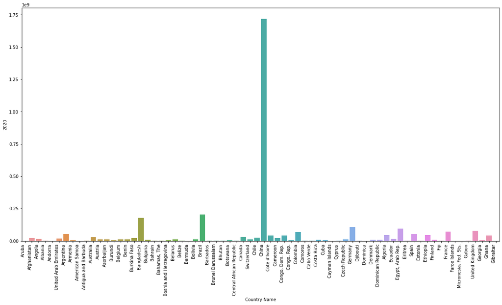

```python
#let us call the function where the input is the first segment
func(df.iloc[:70,:])
```

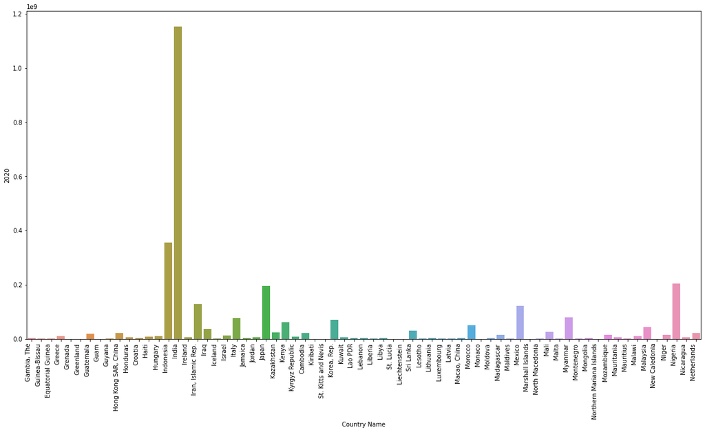

```python
func(df.iloc[71:140,:])
```

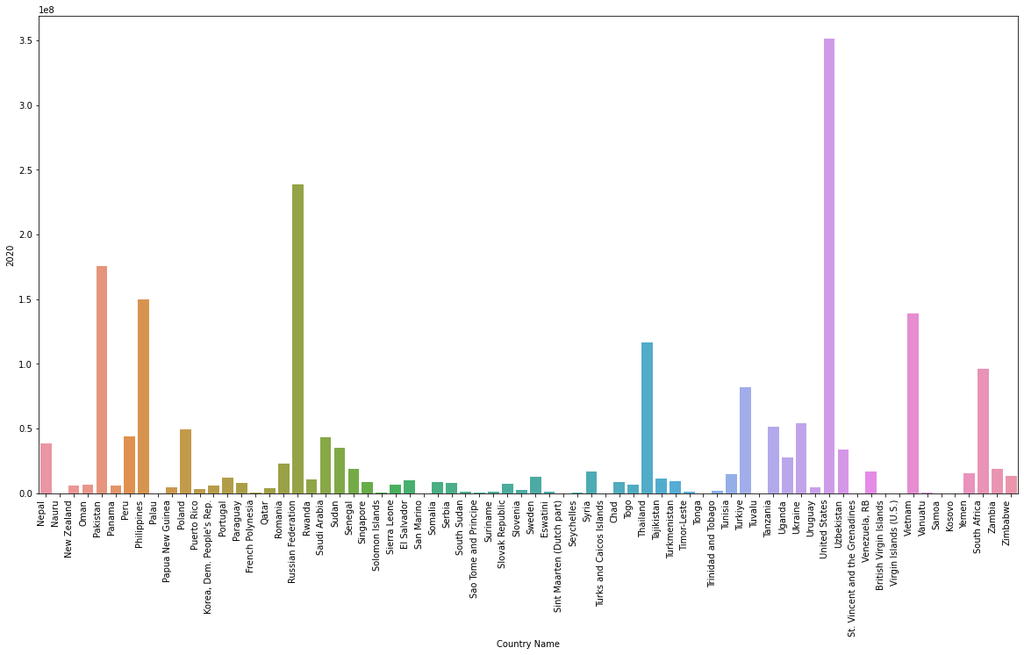

```python
#this bar chart shows the third segment in our dataset
func(df.iloc[141:211,:])
```

In order to answer the question, we have to compare these three bar charts, then we have specify the country which has the highest number of cell phone owners in 2020. That is China, it had a large number of mobile cell phones in 2020.

### 2. In which year did the number of cell phones that have been using reach in 1 billion?

```python
#to answer this question, I have take sample of the dataset, for example, the first 25 columns excluding country column
#contain the year which the number of cell phones reached 1 billion in number through out the world

#so this code below chooses the first 25 columns excluding the country column.
w = df.iloc[:,1:25].sum(axis=0)

#in here, each column contains the total number of cell phones in every country with in specific year. let us look at it
w

#when you run the code, you will first see that i.e, in 1980, the total number of cell phones that have been used through out
#the world is 23482
```

```
1980    2.348200e+04
1981    6.358500e+04
1982    1.015090e+05
1983    1.488550e+05
1984    3.192520e+05
1985    7.506290e+05
1986    1.450136e+06
1987    2.545270e+06
1988    4.327956e+06
1989    7.315671e+06
1990    1.112663e+07
1991    1.607971e+07
1992    2.286038e+07
1993    3.362494e+07
1994    5.492731e+07
1995    8.996794e+07
1996    1.440652e+08
1997    2.134492e+08
1998    3.133509e+08
1999    4.794131e+08
2000    7.201950e+08
2001    9.389141e+08
2002    1.139485e+09
2003    1.388740e+09
dtype: float64
```

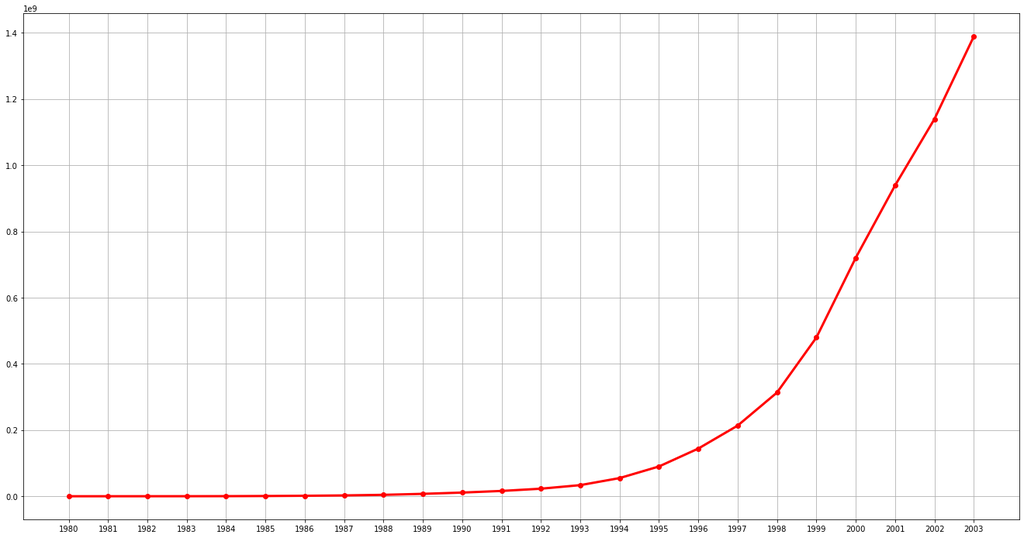

```python
#in order to get the first year that the total number of phones reached in 1 million, we have visualize our dataset by using
#line plot, so this is the result
plt.figure(figsize = (23,12));
gr = plt.plot(w,'ro-',linewidth=3)
plt.grid()
```

So, the answer of the above question is 2002, this is the year that the total number of cell phones through out the world reachd 1 Billion in number.

### 3. In 2000, the world population was estimated 6.143 billion by UN world population prospects [(refer),](https://www.worldometers.info/world-population/world-population-by-year/) So, what percentage of the world population has access to cell phones in 2000?

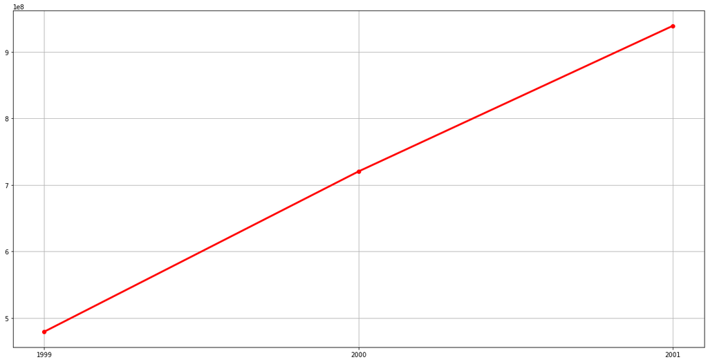

```python
#referrint to the above figure which tells total number of cell phones per year, we can say that the number of peaple those had
#access to cell phonse in 2000 was approximately 700 million.

w = df.iloc[:,20:23].sum(axis=0)
plt.figure(figsize = (20,10));
gr = plt.plot(w,'ro-',linewidth=3)
plt.grid()
```

```python
#in order to know the exact value, we can use sum function
df['2000'].sum()

#the percentage of the world population that had access to cell phones in 2000 can be found by this code.

percent = df['2000'].sum()/6143000000*100
percent

#so, 11.7% of the world population at that time (2000) had access to cell phones
```

```
11.723831873677357
```

### 4. Which country was having the highest number of cell phones in end of last century?

```python
#to answer this question, we need to refer question 1, we need to segment our dataset into three segments as question.
#only the years becomes the end of 20 century which 2000.
df1 = df.iloc[:70,:]
df2 = df.iloc[71:140,:]
df3 = df.iloc[141:211,:]
```

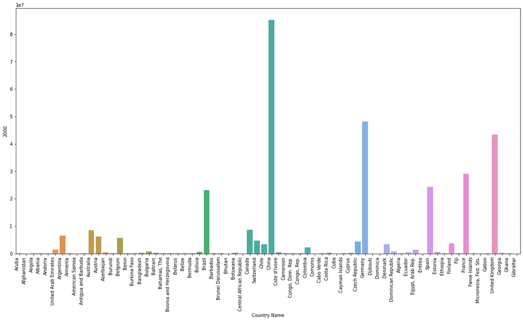

```python
#this bar chart shows the first segment in our dataset
plt.figure(figsize = (20,10))
en = sns.barplot(x = "Country Name", y = '2000', data = df1)
en.set_xticklabels(en.get_xticklabels(),
                          rotation=90,
                          horizontalalignment='right');
```

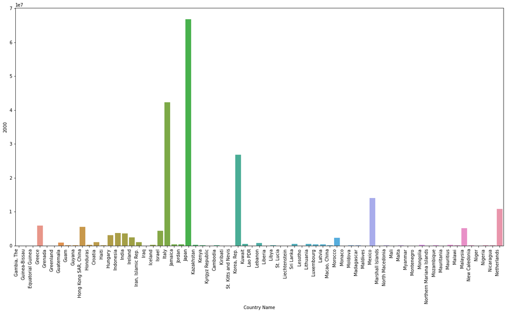

```python
#this bar chart shows the second segment in our dataset
plt.figure(figsize = (20,10));
en1 = sns.barplot(x = "Country Name", y = '2000', data = df2)
en1.set_xticklabels(en1.get_xticklabels(),
                          rotation=90,
                          horizontalalignment='right');
```

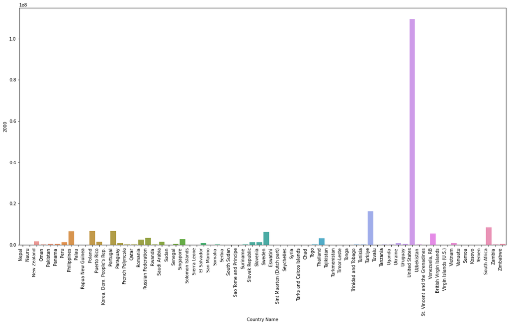

```python
#this bar chart shows the third segment in our dataset
plt.figure(figsize = (20,10));
en2 = sns.barplot(x = "Country Name", y = '2000', data = df3)
en2.set_xticklabels(en2.get_xticklabels(),
                          rotation=90,
                          horizontalalignment='right');
```

So, the answer of question 4 is United States of America.

# Conclusions

In this project, I have investigated the global cell phone dataset of the last four decades. I have araised four question and answered. The first question is about the country with the highest number of cell phone owners in 2020, and answer became China, since it has the highest number of population in the world at this time. The second question was which year did the number of cell phones that have been using reach in 1 billion, and the answer that we have got from the analysis became year 2002. The third question was describing that in 2000, the world population was estimated 6.143 billion by [(UN world population prospects),](https://www.worldometers.info/world-population/world-population-by-year/) So, what percentage of the world population has access to cell phones in 2000? From the analysis I have made, the answer which I have got is 11.7 percent of the world population. The last question which in the Asking questions is Which country was having the highest number of cell phones in end of the last century? The answer of this question became USA. The dataset is not updated, the number of cell phones that have been used for the last two years are not included in this data set. This is the limitation which I have got in the dataset.

```python
from subprocess import call
call(['python', '-m', 'nbconvert', 'Investigate_a_Dataset.ipynb'])
```

```
1
```